# Introduction to ghgtools

Open source GHG accounting software developed by CARML

**ghgtools** is a project of the Carbon Accounting, Reporting, and Management lab [(CARML)](https://carml.rc.nau.edu/). Tracking, measuring, and reporting GHG emissions is essential to understand risks and identify opportunities related to climate change and the transition towards a renewable energy economy. Our mission is to grow the practice of GHG accounting with tools rooted in uncompromising transparency, rigorous data quality, and purposeful versatility.

## The Basics

The GHG inventory of any entity can be summarized as follows: *Assets*, such as buildings, vehicles, and equipment, engage in *Activities*, such as electricity consumption, travel, or purchasing, which each have a specific *Emission Factor* that tells us the rate at which that activity generates GHG emissions. These three variables - assets, actives, and emission factors - compose the underlying calculation methodology. ghgtools uses a set of standardized data templates to match each record of activity data to an emission factor using information about your assets. Our methodology is built on the best practices set forth by the [GHG Protocol Corporate Standard](https://ghgprotocol.org/corporate-standard).

The following datasheets are required to use ghgtools and calculate GHG emissions:

**Asset_Portfolio** - The list of all your assets. This likely includes buildings and vehicles. You may also designate an *Enterprise* asset to calculate scope 3 emissions for purchasing, business travel, and other supply chain related activities.

**Activity_Data** - The record of energy consumption and other GHG-producing activities across each of your assets.

**Emission_Factor_Library** - The catalog of emission factors for a variety of activities. Our team consolidates emission factors from a collection of reputable sources, such as the EPA’s [Emission Factor Hub](https://www.epa.gov/climateleadership/ghg-emission-factors-hub). Unless you want to add your own custom emission factors (which you certainly can, these tools are open source after all!), you don’t need to worry about the emission factor library. It is pre-populated and ready to go.

## How it Works

Most of the functionality in ghgtools comes from the [data.table](https://cran.r-project.org/web/packages/data.table/vignettes/datatable-intro.html) package. This package provides powerful functionality for manipulating date tables.

```r
library(data.table)
```

In order to consolidate emissions data across multiple greenhouse gasses, we need to select global warming potentials (GWPs). You can learn more about different values of global warming potentials by follwoing [this link](https://www.epa.gov/ghgemissions/understanding-global-warming-potentials). ghgtools defaults to the UNFCCC guidelines, which require the use of GWP values from the IPCC’s Fifth Assessment Report (AR5).

```r
GWP <- "AR5"
```

The emission factor library, abbreviated as EFL, is loaded from the ghgtools directory. The raw form of the EFL has a row of data for each greenhouse gas produced by the activity. For example, burning natural gas will generate CO2, CH4 and N2O. The following code loads the raw EFL and consolidates each activity into the CO2e emission factor using the selected GWPs.

```r
EFL <- fread("EFL.csv")
GWPs <- fread("GWPs.csv")
GWPs <- GWPs[, .(ghg,get(GWP))]
colnames(GWPs)[2] <- "GWP"
EFL_CO2e <- data.table(merge.data.table(EFL, GWPs, sort = FALSE, all.x = TRUE))
EFL_CO2e[, sum_co2e := ghg_emission_factor * GWP]
EFL_CO2e <- EFL_CO2e[, .(kgco2e_perunit = sum(sum_co2e)), by = .(ef_source, ef_publishdate, ef_activeyear, service_type, unit, emission_category, service_subcategory1, service_subcategory2, emission_scope, country, subregion)]
EFL_CO2e[, ef_publishdate := format(ef_publishdate, "%m/%d/%Y")]
EFL_CO2e[EFL_CO2e == ""] <- NA
setnames(EFL_CO2e, "ef_activeyear", "year")
```

You can browse the emission factor library below:

| ef_source | ef_publishdate | year | service_type | unit | emission_category | service_subcategory1 | service_subcategory2 | emission_scope | country | subregion | kgco2e_perunit |
| --- | --- | --- | --- | --- | --- | --- | --- | --- | --- | --- | --- |
| EPA CCCL Emission Factors for GHG Inventories | 09/12/2023 | 2023 | Aviation Gasoline | gallons | Mobile |  |  | Scope 1 | United States |  | 8.3100000 |
| EPA CCCL Emission Factors for GHG Inventories | 09/12/2023 | 2023 | Biodiesel (100%) | gallons | Mobile |  |  | Scope 1 | United States |  | 9.4500000 |
| EPA CCCL Emission Factors for GHG Inventories | 09/12/2023 | 2023 | Compressed Natural Gas (CNG) | scf | Mobile |  |  | Scope 1 | United States |  | 0.0544400 |
| EPA CCCL Emission Factors for GHG Inventories | 09/12/2023 | 2023 | Diesel Fuel | gallons | Mobile |  |  | Scope 1 | United States |  | 10.2100000 |
| EPA CCCL Emission Factors for GHG Inventories | 09/12/2023 | 2023 | Ethanol (100%) | gallons | Mobile |  |  | Scope 1 | United States |  | 5.7500000 |
| EPA CCCL Emission Factors for GHG Inventories | 09/12/2023 | 2023 | Kerosene-Type Jet Fuel | gallons | Mobile |  |  | Scope 1 | United States |  | 9.7500000 |
| EPA CCCL Emission Factors for GHG Inventories | 09/12/2023 | 2023 | Liquefied Natural Gas (LNG) | gallons | Mobile |  |  | Scope 1 | United States |  | 4.5000000 |
| EPA CCCL Emission Factors for GHG Inventories | 09/12/2023 | 2023 | Liquefied Petroleum Gases (LPG) | gallons | Mobile |  |  | Scope 1 | United States |  | 5.6800000 |
| EPA CCCL Emission Factors for GHG Inventories | 09/12/2023 | 2023 | Motor Gasoline | gallons | Mobile |  |  | Scope 1 | United States |  | 8.7800000 |
| EPA CCCL Emission Factors for GHG Inventories | 09/12/2023 | 2023 | Residual Fuel Oil | gallons | Mobile |  |  | Scope 1 | United States |  | 11.2700000 |
| EPA CCCL Emission Factors for GHG Inventories | 09/12/2023 | 2023 | Asphalt and Road Oil | gallons | Stationary |  |  | Scope 1 | United States |  | 11.9470100 |
| EPA CCCL Emission Factors for GHG Inventories | 09/12/2023 | 2023 | Aviation Gasoline | gallons | Stationary |  |  | Scope 1 | United States |  | 8.3386300 |
| EPA CCCL Emission Factors for GHG Inventories | 09/12/2023 | 2023 | Butane | gallons | Stationary |  |  | Scope 1 | United States |  | 6.6945800 |
| EPA CCCL Emission Factors for GHG Inventories | 09/12/2023 | 2023 | Butylene | gallons | Stationary |  |  | Scope 1 | United States |  | 7.2448600 |
| EPA CCCL Emission Factors for GHG Inventories | 09/12/2023 | 2023 | Crude Oil | gallons | Stationary |  |  | Scope 1 | United States |  | 10.3226800 |
| EPA CCCL Emission Factors for GHG Inventories | 09/12/2023 | 2023 | Distillate Fuel Oil No. 1 | gallons | Stationary |  |  | Scope 1 | United States |  | 10.2129600 |
| EPA CCCL Emission Factors for GHG Inventories | 09/12/2023 | 2023 | Distillate Fuel Oil No. 2 | gallons | Stationary |  |  | Scope 1 | United States |  | 10.2426800 |
| EPA CCCL Emission Factors for GHG Inventories | 09/12/2023 | 2023 | Distillate Fuel Oil No. 4 | gallons | Stationary |  |  | Scope 1 | United States |  | 10.9961700 |
| EPA CCCL Emission Factors for GHG Inventories | 09/12/2023 | 2023 | Ethane | gallons | Stationary |  |  | Scope 1 | United States |  | 4.0662000 |
| EPA CCCL Emission Factors for GHG Inventories | 09/12/2023 | 2023 | Ethylene | gallons | Stationary |  |  | Scope 1 | United States |  | 3.8427100 |
| EPA CCCL Emission Factors for GHG Inventories | 09/12/2023 | 2023 | Heavy Gas Oils | gallons | Stationary |  |  | Scope 1 | United States |  | 11.1261700 |
| EPA CCCL Emission Factors for GHG Inventories | 09/12/2023 | 2023 | Isobutane | gallons | Stationary |  |  | Scope 1 | United States |  | 6.4543000 |
| EPA CCCL Emission Factors for GHG Inventories | 09/12/2023 | 2023 | Isobutylene | gallons | Stationary |  |  | Scope 1 | United States |  | 7.1145800 |
| EPA CCCL Emission Factors for GHG Inventories | 09/12/2023 | 2023 | Kerosene | gallons | Stationary |  |  | Scope 1 | United States |  | 10.1826800 |
| EPA CCCL Emission Factors for GHG Inventories | 09/12/2023 | 2023 | Kerosene-Type Jet Fuel | gallons | Stationary |  |  | Scope 1 | United States |  | 9.7826800 |
| EPA CCCL Emission Factors for GHG Inventories | 09/12/2023 | 2023 | Liquefied Petroleum Gases (LPG) | gallons | Stationary |  |  | Scope 1 | United States |  | 5.7037400 |
| EPA CCCL Emission Factors for GHG Inventories | 09/12/2023 | 2023 | Lubricants | gallons | Stationary |  |  | Scope 1 | United States |  | 10.7258900 |
| EPA CCCL Emission Factors for GHG Inventories | 09/12/2023 | 2023 | Motor Gasoline | gallons | Stationary |  |  | Scope 1 | United States |  | 8.8118400 |
| EPA CCCL Emission Factors for GHG Inventories | 09/12/2023 | 2023 | Naphtha (<401 deg F) | gallons | Stationary |  |  | Scope 1 | United States |  | 8.5318400 |
| EPA CCCL Emission Factors for GHG Inventories | 09/12/2023 | 2023 | Natural Gas | scf | Stationary |  |  | Scope 1 | United States |  | 0.0544953 |

[output cut: 2140 more lines]

Now we must populate our asset portfolio and activity data. This tutorial includes a set of example data. We load the asset portoflio and activity data from files in our directory.

**Asset Portfolio**

| asset_id | address | city | state | zip | country | sqft | region | business_unit | asset_type | asset_subtype | year_built |
| --- | --- | --- | --- | --- | --- | --- | --- | --- | --- | --- | --- |
| B1456 |  | Bellingham | Washington | 98226 | United States | 342 | West Coast | Operations | Building | Office | 1993 |
| B1457 |  | Bellingham | Washington | 98225 | United States | 3280 | West Coast | Operations | Building | Office | 2005 |
| B1458 |  | Bellingham | Washington | 98225 | United States | 20142 | West Coast | Operations | Building | Office | 2003 |
| B1564 |  | Woodinville | Washington | 98072 | United States | 3636 | West Coast | Operations | Building | Office | 1990 |
| B1662 |  | Portland | Oregon | 97202 | United States | 4821 | West Coast | Operations | Building | Office | 2007 |
| B1663 |  | Portland | Oregon | 97229 | United States | 4316 | West Coast | Operations | Building | Office | 2015 |
| B1866 |  | Sacramento | California | 95816 | United States | 6074 | West Coast | Operations | Building | Office | 1999 |
| B1867 |  | Sacramento | California | 95825 | United States | 3959 | West Coast | Operations | Building | Office | 2004 |
| B1868 |  | Sacramento | California | 95825 | United States | 8070 | West Coast | Operations | Building | Office | 2004 |
| B2074 |  | Indio | California | 92203 | United States | 3543 | West Coast | Operations | Building | Office | 2010 |
| Enterprise |  |  |  |  | United States |  | West Coast |  | Enterprise |  |  |

**Activity Data**

| asset_id | vendor | account_id | meter_number | date | year | cost | service_type | service_subcategory1 | service_subcategory2 | unit | usage |
| --- | --- | --- | --- | --- | --- | --- | --- | --- | --- | --- | --- |
| B1456 |  |  |  |  | 2023 |  | Electricity |  |  | kWh | 31231.907 |
| B1457 |  |  |  |  | 2023 |  | Electricity |  |  | kWh | 19389.588 |
| B1458 |  |  |  |  | 2023 |  | Electricity |  |  | kWh | 185862.407 |
| B1458 |  |  |  |  | 2023 |  | Natural Gas |  |  | therms | 2569.690 |
| B1564 |  |  |  |  | 2023 |  | Electricity |  |  | kWh | 47302.603 |
| B1564 |  |  |  |  | 2023 |  | Natural Gas |  |  | therms | 1382.843 |
| B1662 |  |  |  |  | 2023 |  | Electricity |  |  | kWh | 106760.001 |
| B1662 |  |  |  |  | 2023 |  | Natural Gas |  |  | therms | 3541.052 |
| B1663 |  |  |  |  | 2023 |  | Electricity |  |  | kWh | 74746.451 |
| B1663 |  |  |  |  | 2023 |  | Natural Gas |  |  | therms | 1793.131 |
| B1866 |  |  |  |  | 2023 |  | Electricity |  |  | kWh | 85928.162 |
| B1867 |  |  |  |  | 2023 |  | Electricity |  |  | kWh | 44956.454 |
| B1868 |  |  |  |  | 2023 |  | Electricity |  |  | kWh | 106728.394 |
| B2074 |  |  |  |  | 2023 |  | Electricity |  |  | kWh | 49348.000 |
| B2074 |  |  |  |  | 2023 |  | Natural Gas |  |  | therms | 25.981 |
| Enterprise |  |  |  |  | 2023 |  | Capital Goods | Manufacturing | Electronic Computer Manufacturing | USD | 22219.240 |
| Enterprise |  |  |  |  | 2023 |  | Capital Goods | Manufacturing | All Other Miscellaneous General Purpose Machinery Manufacturing | USD | 424731.110 |
| Enterprise |  |  |  |  | 2023 |  | Purchased Goods and Services | Professional, Scientific, and Technical Services | All Other Legal Services | USD | 533840.640 |
| Enterprise |  |  |  |  | 2023 |  | Purchased Goods and Services | Professional, Scientific, and Technical Services | Human Resources Consulting Services | USD | 130615.220 |
| Enterprise |  |  |  |  | 2023 |  | Purchased Goods and Services | Professional, Scientific, and Technical Services | Landscape Architectural Services | USD | 988346.400 |
| Enterprise |  |  |  |  | 2023 |  | Purchased Goods and Services | Administrative and Support and Waste Mgmt. Services | Facilities Support Services | USD | 154157.660 |
| Enterprise |  |  |  |  | 2023 |  | Purchased Goods and Services | Administrative and Support and Waste Mgmt. Services | Janitorial Services | USD | 42621.180 |
| Enterprise |  |  |  |  | 2023 |  | Purchased Goods and Services | Administrative and Support and Waste Mgmt. Services | Office Administrative Services | USD | 160131.340 |
| Enterprise |  |  |  |  | 2023 |  | Purchased Goods and Services | Administrative and Support and Waste Mgmt. Services | Security Systems Services (except Locksmiths) | USD | 15929.275 |
| Enterprise |  |  |  |  | 2023 |  | Purchased Goods and Services | Educational Services | Professional and Management Development Training | USD | 321181.500 |
| Enterprise |  |  |  |  | 2023 |  | Purchased Goods and Services | Information | Wireless Telecommunications Carriers (except Satellite) | USD | 1795761.130 |
| Enterprise |  |  |  |  | 2023 |  | Business Travel | Ground Travel | Passenger Car | vehicle-mile | 15000.000 |
| Enterprise |  |  |  |  | 2023 |  | Business Travel | Ground Travel | Light-Duty Truck | vehicle-mile | 500.000 |
| Enterprise |  |  |  |  | 2023 |  | Business Travel | Rail Travel | Intercity Rail - National Average | passenger-mile | 37000.000 |
| Enterprise |  |  |  |  | 2023 |  | Business Travel | Air Travel | Air Travel - Short Haul | passenger-mile | 60000.000 |
| Enterprise |  |  |  |  | 2023 |  | Business Travel | Air Travel | Air Travel - Medium Haul | passenger-mile | 110000.000 |
| Enterprise |  |  |  |  | 2023 |  | Business Travel | Air Travel | Air Travel - Long Haul | passenger-mile | 73000.000 |
| Enterprise |  |  |  |  | 2023 |  | Employee Commuting | Ground Travel | Passenger Car | vehicle-mile | 70000.000 |
| Enterprise |  |  |  |  | 2023 |  | Employee Commuting | Rail Travel | Transit Rail | passenger-mile | 84000.000 |
| Enterprise |  |  |  |  | 2023 |  | Employee Commuting | Ground Travel | Bus | passenger-mile | 3000.000 |

At this point, we have defined each of the required input variables - assets, activities, and emission factors - and loaded the data in the required templates. The following code combines these three datasheets, assignes emission factors, and calculates GHG emissions for each record of activity data.

```r
eGRIDlookup <- fread("eGRID_lookup.csv")
Ecat_lookup <- fread("Ecat_lookup.csv")
DT1 <- fread("ActivityData.csv")
DT1[DT1 == ""] <- NA
DT2 <- data.table(merge.data.table(DT1, AssetPortfolio, sort = FALSE, all.x = TRUE))
DT3 <- data.table(merge.data.table(DT2, Ecat_lookup, by = c("asset_type", "service_type"), sort = FALSE))
DT4 <- data.table(merge.data.table(DT3, eGRIDlookup, sort = FALSE, all.x = TRUE))
GHGrawdata <- data.table(merge.data.table(DT4, EFL_CO2e, by = c("year", "service_type", "emission_category", "service_subcategory1", "service_subcategory2", "country", "subregion", "unit"), all.x = TRUE, sort = FALSE))
GHGrawdata[, kg_co2e := usage * kgco2e_perunit]
GHGrawdata[, mt_co2e := kg_co2e/1000]
setcolorder(GHGrawdata, c("asset_id", "asset_type", "asset_subtype", "address", "city", "state", "zip", "country", "region", "subregion", "business_unit", "year_built", "sqft", "service_type", "unit", "vendor", "account_id", "meter_number", "date", "year", "cost", "usage", "emission_category", "service_subcategory1", "service_subcategory2", "emission_scope", "kgco2e_perunit", "kg_co2e", "mt_co2e", "ef_source", "ef_publishdate"))
GHGrawdata[is.na(GHGrawdata)] <- ""
fwrite(GHGrawdata, "GHGrawdata.csv")
```

The GHG inventory raw data output looks like this:

| asset_id | asset_type | asset_subtype | address | city | state | zip | country | region | subregion | business_unit | year_built | sqft | service_type | unit | vendor | account_id | meter_number | date | year | cost | usage | emission_category | service_subcategory1 | service_subcategory2 | emission_scope | kgco2e_perunit | kg_co2e | mt_co2e | ef_source | … |
| --- | --- | --- | --- | --- | --- | --- | --- | --- | --- | --- | --- | --- | --- | --- | --- | --- | --- | --- | --- | --- | --- | --- | --- | --- | --- | --- | --- | --- | --- | --- |
| B1456 | Building | Office |  | Bellingham | Washington | 98226 | United States | West Coast | NWPP | Operations | 1993 | 342 | Electricity | kWh |  |  |  |  | 2023 |  | 31231.907 | Indirect Energy |  |  | Scope 2 | 0.2747753 | 8581.7574 | 8.5817574 | USEPA eGRID2022 | … |
| B1457 | Building | Office |  | Bellingham | Washington | 98225 | United States | West Coast | NWPP | Operations | 2005 | 3280 | Electricity | kWh |  |  |  |  | 2023 |  | 19389.588 | Indirect Energy |  |  | Scope 2 | 0.2747753 | 5327.7803 | 5.3277803 | USEPA eGRID2022 | … |
| B1458 | Building | Office |  | Bellingham | Washington | 98225 | United States | West Coast | NWPP | Operations | 2003 | 20142 | Electricity | kWh |  |  |  |  | 2023 |  | 185862.407 | Indirect Energy |  |  | Scope 2 | 0.2747753 | 51070.4032 | 51.0704032 | USEPA eGRID2022 | … |
| B1458 | Building | Office |  | Bellingham | Washington | 98225 | United States | West Coast |  | Operations | 2003 | 20142 | Natural Gas | therms |  |  |  |  | 2023 |  | 2569.690 | Stationary |  |  | Scope 1 | 5.3114500 | 13648.7800 | 13.6487800 | EPA CCCL Emission Factors for GHG Inventories | … |
| B1564 | Building | Office |  | Woodinville | Washington | 98072 | United States | West Coast | NWPP | Operations | 1990 | 3636 | Electricity | kWh |  |  |  |  | 2023 |  | 47302.603 | Indirect Energy |  |  | Scope 2 | 0.2747753 | 12997.5881 | 12.9975881 | USEPA eGRID2022 | … |
| B1564 | Building | Office |  | Woodinville | Washington | 98072 | United States | West Coast |  | Operations | 1990 | 3636 | Natural Gas | therms |  |  |  |  | 2023 |  | 1382.843 | Stationary |  |  | Scope 1 | 5.3114500 | 7344.9015 | 7.3449015 | EPA CCCL Emission Factors for GHG Inventories | … |
| B1662 | Building | Office |  | Portland | Oregon | 97202 | United States | West Coast | NWPP | Operations | 2007 | 4821 | Electricity | kWh |  |  |  |  | 2023 |  | 106760.001 | Indirect Energy |  |  | Scope 2 | 0.2747753 | 29335.0139 | 29.3350139 | USEPA eGRID2022 | … |
| B1662 | Building | Office |  | Portland | Oregon | 97202 | United States | West Coast |  | Operations | 2007 | 4821 | Natural Gas | therms |  |  |  |  | 2023 |  | 3541.052 | Stationary |  |  | Scope 1 | 5.3114500 | 18808.1206 | 18.8081206 | EPA CCCL Emission Factors for GHG Inventories | … |
| B1663 | Building | Office |  | Portland | Oregon | 97229 | United States | West Coast | NWPP | Operations | 2015 | 4316 | Electricity | kWh |  |  |  |  | 2023 |  | 74746.451 | Indirect Energy |  |  | Scope 2 | 0.2747753 | 20538.4803 | 20.5384803 | USEPA eGRID2022 | … |
| B1663 | Building | Office |  | Portland | Oregon | 97229 | United States | West Coast |  | Operations | 2015 | 4316 | Natural Gas | therms |  |  |  |  | 2023 |  | 1793.131 | Stationary |  |  | Scope 1 | 5.3114500 | 9524.1256 | 9.5241256 | EPA CCCL Emission Factors for GHG Inventories | … |
| B1866 | Building | Office |  | Sacramento | California | 95816 | United States | West Coast | CAMX | Operations | 1999 | 6074 | Electricity | kWh |  |  |  |  | 2023 |  | 85928.162 | Indirect Energy |  |  | Scope 2 | 0.2264981 | 19462.5685 | 19.4625685 | USEPA eGRID2022 | … |
| B1867 | Building | Office |  | Sacramento | California | 95825 | United States | West Coast | CAMX | Operations | 2004 | 3959 | Electricity | kWh |  |  |  |  | 2023 |  | 44956.454 | Indirect Energy |  |  | Scope 2 | 0.2264981 | 10182.5530 | 10.1825530 | USEPA eGRID2022 | … |
| B1868 | Building | Office |  | Sacramento | California | 95825 | United States | West Coast | CAMX | Operations | 2004 | 8070 | Electricity | kWh |  |  |  |  | 2023 |  | 106728.394 | Indirect Energy |  |  | Scope 2 | 0.2264981 | 24173.7823 | 24.1737823 | USEPA eGRID2022 | … |
| B2074 | Building | Office |  | Indio | California | 92203 | United States | West Coast | AZNM | Operations | 2010 | 3543 | Electricity | kWh |  |  |  |  | 2023 |  | 49348.000 | Indirect Energy |  |  | Scope 2 | 0.3534931 | 17444.1771 | 17.4441771 | USEPA eGRID2022 | … |
| B2074 | Building | Office |  | Indio | California | 92203 | United States | West Coast |  | Operations | 2010 | 3543 | Natural Gas | therms |  |  |  |  | 2023 |  | 25.981 | Stationary |  |  | Scope 1 | 5.3114500 | 137.9968 | 0.1379968 | EPA CCCL Emission Factors for GHG Inventories | … |
| Enterprise | Enterprise |  |  |  |  |  | United States | West Coast |  |  |  |  | Capital Goods | USD |  |  |  |  | 2023 |  | 22219.240 | Capital Goods | Manufacturing | Electronic Computer Manufacturing | Scope 3 | 0.0998362 | 2218.2850 | 2.2182850 | US EPA Supply Chain Emission Factors | … |
| Enterprise | Enterprise |  |  |  |  |  | United States | West Coast |  |  |  |  | Capital Goods | USD |  |  |  |  | 2023 |  | 424731.110 | Capital Goods | Manufacturing | All Other Miscellaneous General Purpose Machinery Manufacturing | Scope 3 | 0.2303679 | 97844.4285 | 97.8444285 | US EPA Supply Chain Emission Factors | … |
| Enterprise | Enterprise |  |  |  |  |  | United States | West Coast |  |  |  |  | Purchased Goods and Services | USD |  |  |  |  | 2023 |  | 533840.640 | Purchased Goods and Services | Professional, Scientific, and Technical Services | All Other Legal Services | Scope 3 | 0.0481355 | 25696.6934 | 25.6966934 | US EPA Supply Chain Emission Factors | … |
| Enterprise | Enterprise |  |  |  |  |  | United States | West Coast |  |  |  |  | Purchased Goods and Services | USD |  |  |  |  | 2023 |  | 130615.220 | Purchased Goods and Services | Professional, Scientific, and Technical Services | Human Resources Consulting Services | Scope 3 | 0.0755089 | 9862.6153 | 9.8626153 | US EPA Supply Chain Emission Factors | … |
| Enterprise | Enterprise |  |  |  |  |  | United States | West Coast |  |  |  |  | Purchased Goods and Services | USD |  |  |  |  | 2023 |  | 988346.400 | Purchased Goods and Services | Professional, Scientific, and Technical Services | Landscape Architectural Services | Scope 3 | 0.1108301 | 109538.5704 | 109.5385704 | US EPA Supply Chain Emission Factors | … |
| Enterprise | Enterprise |  |  |  |  |  | United States | West Coast |  |  |  |  | Purchased Goods and Services | USD |  |  |  |  | 2023 |  | 154157.660 | Purchased Goods and Services | Administrative and Support and Waste Mgmt. Services | Facilities Support Services | Scope 3 | 0.1898948 | 29273.7389 | 29.2737389 | US EPA Supply Chain Emission Factors | … |
| Enterprise | Enterprise |  |  |  |  |  | United States | West Coast |  |  |  |  | Purchased Goods and Services | USD |  |  |  |  | 2023 |  | 42621.180 | Purchased Goods and Services | Administrative and Support and Waste Mgmt. Services | Janitorial Services | Scope 3 | 0.1536699 | 6549.5943 | 6.5495943 | US EPA Supply Chain Emission Factors | … |
| Enterprise | Enterprise |  |  |  |  |  | United States | West Coast |  |  |  |  | Purchased Goods and Services | USD |  |  |  |  | 2023 |  | 160131.340 | Purchased Goods and Services | Administrative and Support and Waste Mgmt. Services | Office Administrative Services | Scope 3 | 0.0937597 | 15013.8729 | 15.0138729 | US EPA Supply Chain Emission Factors | … |
| Enterprise | Enterprise |  |  |  |  |  | United States | West Coast |  |  |  |  | Purchased Goods and Services | USD |  |  |  |  | 2023 |  | 15929.275 | Purchased Goods and Services | Administrative and Support and Waste Mgmt. Services | Security Systems Services (except Locksmiths) | Scope 3 | 0.0714570 | 1138.2589 | 1.1382589 | US EPA Supply Chain Emission Factors | … |
| Enterprise | Enterprise |  |  |  |  |  | United States | West Coast |  |  |  |  | Purchased Goods and Services | USD |  |  |  |  | 2023 |  | 321181.500 | Purchased Goods and Services | Educational Services | Professional and Management Development Training | Scope 3 | 0.1119962 | 35971.0919 | 35.9710919 | US EPA Supply Chain Emission Factors | … |
| Enterprise | Enterprise |  |  |  |  |  | United States | West Coast |  |  |  |  | Purchased Goods and Services | USD |  |  |  |  | 2023 |  | 1795761.130 | Purchased Goods and Services | Information | Wireless Telecommunications Carriers (except Satellite) | Scope 3 | 0.1507596 | 270728.2735 | 270.7282735 | US EPA Supply Chain Emission Factors | … |
| Enterprise | Enterprise |  |  |  |  |  | United States | West Coast |  |  |  |  | Business Travel | vehicle-mile |  |  |  |  | 2023 |  | 15000.000 | Business Travel | Ground Travel | Passenger Car | Scope 3 | 0.3150790 | 4726.1850 | 4.7261850 | EPA CCCL Emission Factors for GHG Inventories | … |
| Enterprise | Enterprise |  |  |  |  |  | United States | West Coast |  |  |  |  | Business Travel | vehicle-mile |  |  |  |  | 2023 |  | 500.000 | Business Travel | Ground Travel | Light-Duty Truck | Scope 3 | 0.4705440 | 235.2720 | 0.2352720 | EPA CCCL Emission Factors for GHG Inventories | … |
| Enterprise | Enterprise |  |  |  |  |  | United States | West Coast |  |  |  |  | Business Travel | passenger-mile |  |  |  |  | 2023 |  | 37000.000 | Business Travel | Rail Travel | Intercity Rail - National Average | Scope 3 | 0.1139466 | 4216.0242 | 4.2160242 | EPA CCCL Emission Factors for GHG Inventories | … |
| Enterprise | Enterprise |  |  |  |  |  | United States | West Coast |  |  |  |  | Business Travel | passenger-mile |  |  |  |  | 2023 |  | 60000.000 | Business Travel | Air Travel | Air Travel - Short Haul | Scope 3 | 0.2089282 | 12535.6920 | 12.5356920 | EPA CCCL Emission Factors for GHG Inventories | … |
| Enterprise | Enterprise |  |  |  |  |  | United States | West Coast |  |  |  |  | Business Travel | passenger-mile |  |  |  |  | 2023 |  | 110000.000 | Business Travel | Air Travel | Air Travel - Medium Haul | Scope 3 | 0.1301033 | 14311.3630 | 14.3113630 | EPA CCCL Emission Factors for GHG Inventories | … |
| Enterprise | Enterprise |  |  |  |  |  | United States | West Coast |  |  |  |  | Business Travel | passenger-mile |  |  |  |  | 2023 |  | 73000.000 | Business Travel | Air Travel | Air Travel - Long Haul | Scope 3 | 0.1643948 | 12000.8204 | 12.0008204 | EPA CCCL Emission Factors for GHG Inventories | … |
| Enterprise | Enterprise |  |  |  |  |  | United States | West Coast |  |  |  |  | Employee Commuting | vehicle-mile |  |  |  |  | 2023 |  | 70000.000 | Employee Commuting | Ground Travel | Passenger Car | Scope 3 | 0.3150790 | 22055.5300 | 22.0555300 | EPA CCCL Emission Factors for GHG Inventories | … |
| Enterprise | Enterprise |  |  |  |  |  | United States | West Coast |  |  |  |  | Employee Commuting | passenger-mile |  |  |  |  | 2023 |  | 84000.000 | Employee Commuting | Rail Travel | Transit Rail | Scope 3 | 0.0965155 | 8107.3020 | 8.1073020 | EPA CCCL Emission Factors for GHG Inventories | … |
| Enterprise | Enterprise |  |  |  |  |  | United States | West Coast |  |  |  |  | Employee Commuting | passenger-mile |  |  |  |  | 2023 |  | 3000.000 | Employee Commuting | Ground Travel | Bus | Scope 3 | 0.0554679 | 166.4037 | 0.1664037 | EPA CCCL Emission Factors for GHG Inventories | … |

With our GHG inventory calculated, we can produce a number of charts and visuals to start exploring the data.

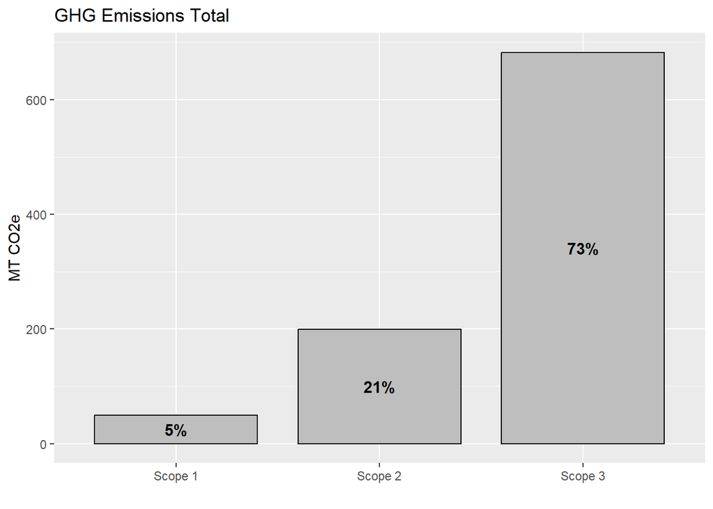

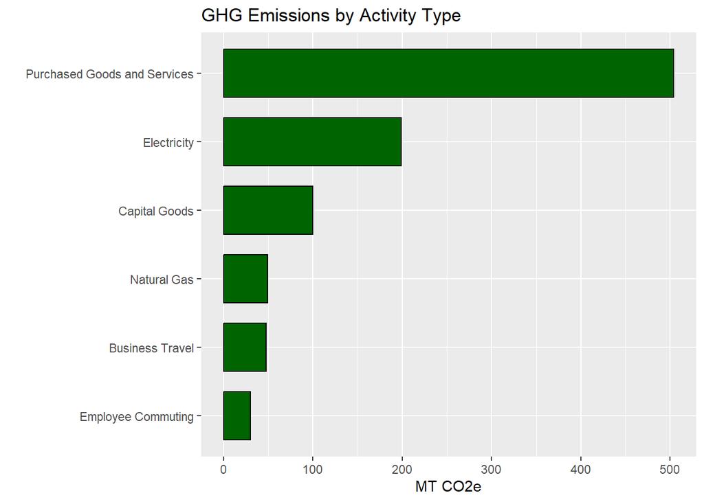

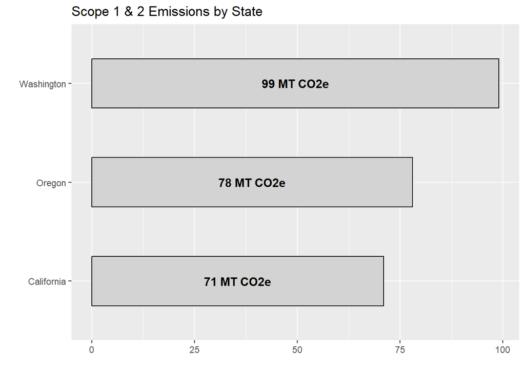

These charts are just the tip of the iceberg. Using [ggplot2](https://r-graph-gallery.com/ggplot2-package.html) we can create a wide variety of charts and data visualizations, with almost infinite customization.

**If you want to start using ghgtools** - follow this link to the ghgtools-template repository on github. You can clone this repository, which has all the data templates, emission factor library, and brief instructions on how to get started.